# 02_data-analysis

Francesco Grassi

2022-10-16

# Aim

Exploratory analysis of the dataset containing the number of deaths in my hometown in the period 01/01/2011 - 31/07/2022.  
Raw data was cleaned and prepared in script “01_clean-data.Rmd” (see script for details).

# Libraries

```r
options(dplyr.summarise.inform = FALSE)
options(dplyr.quiet = TRUE)

library(tidyverse)
library(lubridate)
```

# Load data

Cleaned data is stored in the .csv file “clean-data.csv”, in “data/”.  
Dataset contains one row for each death(s) recorded in a give day in the period 01/01/2011 - 31/07/2022. Dataset columns are:

- Age_Range: age range of the deceased
- Date: date of death in format gg-mm-yy
- Sex: M = male, F = female
- Count: number of deaths recorder in the given day

```r
main <- read_csv(file = "data/clean-data.csv")

head(main)  # Have a look at first rows
```

| Age_Range | Date | Sex | Count |
| --- | --- | --- | --- |
| 0 | 2017-11-12 | F | 1 |
| 40-44 | 2015-03-29 | M | 1 |
| 40-44 | 2022-07-10 | F | 1 |
| 40-44 | 2011-11-09 | M | 1 |
| 40-44 | 2015-11-15 | F | 1 |
| 45-49 | 2022-02-08 | F | 1 |

# Descriptive analysis

Before start checking whether the saying that “people in the hometown die in groups of three”, it’s interesting to get a general idea of the data.set we’re working with.

- Table and plot of deaths per year, divided by sex
- Table and plot of deaths per month, divided by sex
- Table and plot of deaths per age range, divided by sex

## Refine data.frame

Mutate “Age_Range” in an ordered factor.  
Moreover, I know it’s probably unnecessary and inelegant, but I hate the way lubridate treats dates when grouping and summarizing (as will be done in next steps). So for my peace of mind, first of all I’m going to add two new variables to the data.frame, “Month” and “Year”, and use them for further grouping steps:

```r
main <- main %>%
  mutate(Age_Range = factor(Age_Range, levels = c("0", "40-44", "45-49", "50-54", "55-59", "60-64", "65-69", "70-74", "75-79", "80-84", "85-89", "90-94", "95-99", "100+"))) %>%
  mutate(Month = ordered(month(Date, label = TRUE, abbr = TRUE)),
         Year = ordered(year(Date)))
```

## Deaths per year

Summary table:

```r
main %>%
  group_by(Year, Sex) %>%
  summarize(Count = n())
```

| Year | Sex | Count |
| --- | --- | --- |
| 2011 | F | 13 |
| 2011 | M | 15 |
| 2012 | F | 12 |
| 2012 | M | 12 |
| 2013 | F | 2 |
| 2013 | M | 6 |
| 2014 | F | 13 |
| 2014 | M | 11 |
| 2015 | F | 8 |
| 2015 | M | 11 |

[output cut: 14 more lines]

Plot table data as grouped barplot:

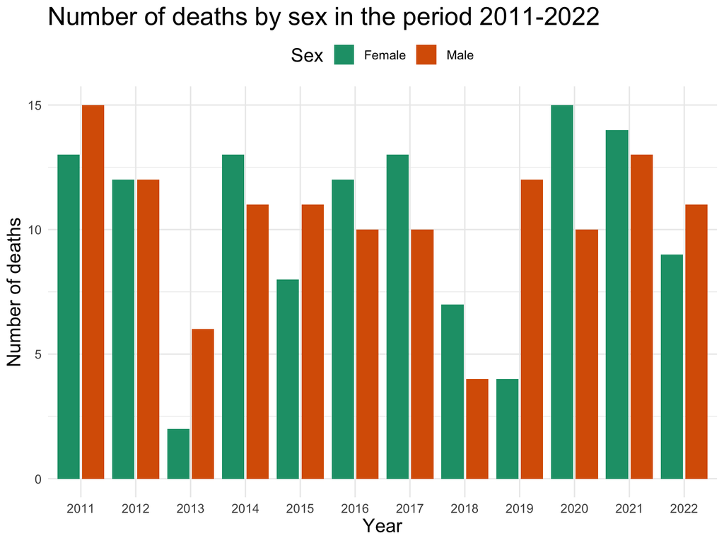

```r
p <- main %>%
  ggplot(aes(x = Year, fill = Sex))

p <- p +
  geom_bar(position = "dodge2") +
  labs(x = "Year", y = "Number of deaths", fill = "Sex") +
  ggtitle("Number of deaths by sex in the period 2011-2022") +
  scale_fill_brewer(labels = c("Female", "Male"), palette = "Dark2") +
  theme_minimal() +
  theme(axis.text = element_text(size = 10),
        axis.title = element_text(size = 15),
        legend.text = element_text(size = 10),
        legend.title = element_text(size = 15),
        legend.position = "top",
        plot.title = element_text(size = 20))

p
```

As we can see, the year with the smallest number of death was 2013 for females, and 2018 for males. The deadliest year was instead 2020 for female, and 2011 for males.

## Deaths per month

Summary table:

```r
main %>%
  group_by(Month, Sex) %>%
  summarize(Count = n())
```

| Month | Sex | Count |
| --- | --- | --- |
| Jan | F | 2 |
| Jan | M | 16 |
| Feb | F | 15 |
| Feb | M | 16 |
| Mar | F | 10 |
| Mar | M | 9 |
| Apr | F | 12 |
| Apr | M | 11 |
| May | F | 5 |
| May | M | 6 |

[output cut: 14 more lines]

Plot table data as grouped barplot:

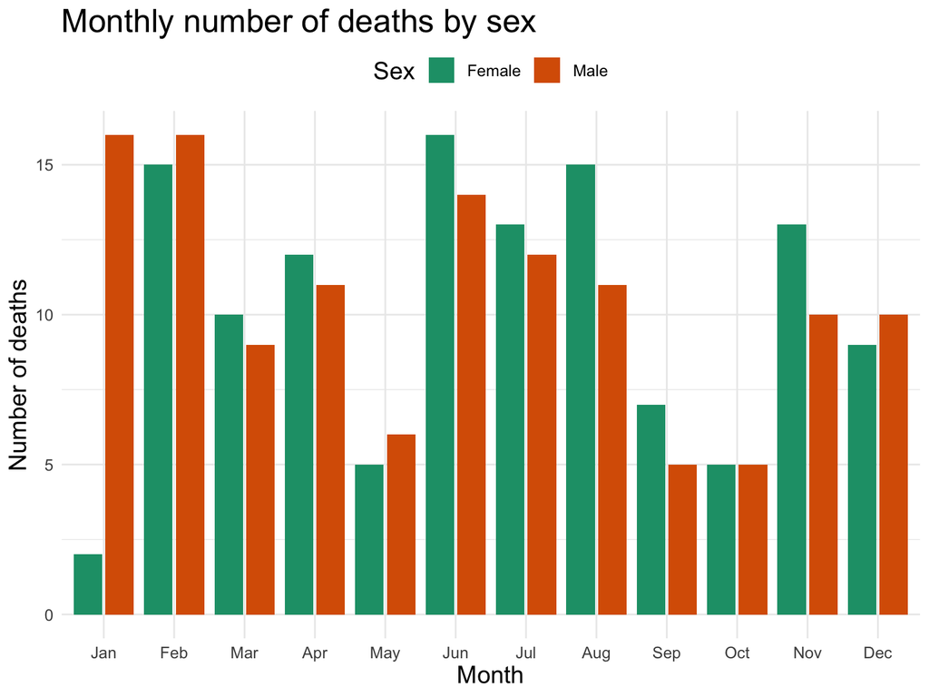

```r
p <- main %>%
  ggplot(aes(x = Month, fill = Sex))

p <- p +
  geom_bar(position = "dodge2") +
  labs(x = "Month", y = "Number of deaths", fill = "Sex") +
  ggtitle("Monthly number of deaths by sex") +
  scale_fill_brewer(labels = c("Female", "Male"), palette = "Dark2") +
  theme_minimal() +
  theme(axis.text = element_text(size = 10),
        axis.title = element_text(size = 15),
        legend.text = element_text(size = 10),
        legend.title = element_text(size = 15),
        legend.position = "top",
        plot.title = element_text(size = 20))

p
```

Here we can see what it looks like two peaks of mortality across the year: one in the winter months (roughly Nov-Feb), and one in the summer months (roughly Jun-Aug).

## Deaths per age range

Summary table:

```r
main %>%
  group_by(Age_Range, Sex) %>%
  summarize(Count = n())
```

| Age_Range | Sex | Count |
| --- | --- | --- |
| 0 | F | 1 |
| 40-44 | F | 2 |
| 40-44 | M | 2 |
| 45-49 | F | 3 |
| 45-49 | M | 2 |
| 50-54 | F | 2 |
| 50-54 | M | 2 |
| 55-59 | F | 2 |
| 55-59 | M | 3 |
| 60-64 | F | 2 |

[output cut: 17 more lines]

Plot table data as grouped barplot:

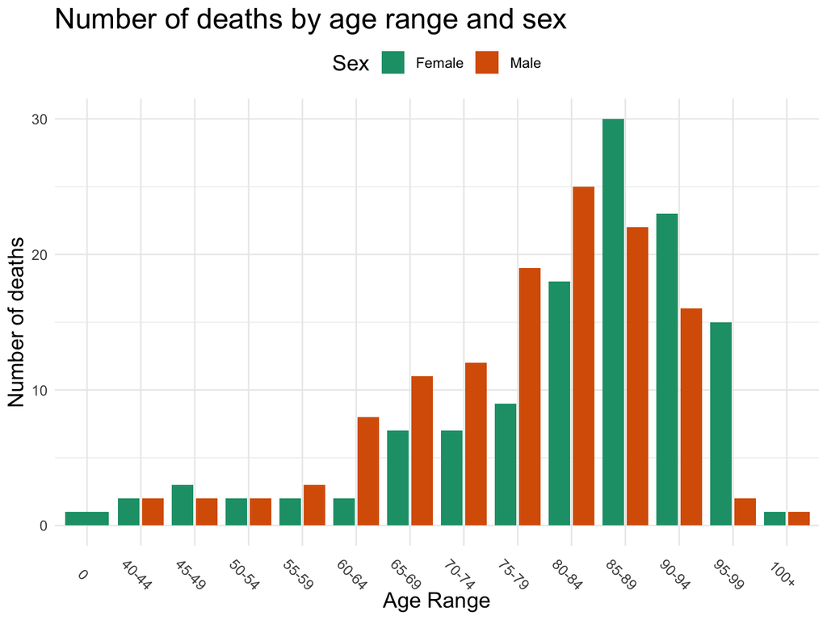

```r
p <- main %>%
  ggplot(aes(x = Age_Range, fill = Sex))

p <- p +
  geom_bar(position = "dodge2") +
  labs(x = "Age Range", y = "Number of deaths", fill = "Sex") +
  ggtitle("Number of deaths by age range and sex") +
  scale_fill_brewer(labels = c("Female", "Male"), palette = "Dark2") +
  theme_minimal() +
  theme(axis.text = element_text(size = 10),
        axis.text.x = element_text(angle = -45),
        axis.title = element_text(size = 15),
        legend.text = element_text(size = 10),
        legend.title = element_text(size = 15),
        legend.position = "top",
        plot.title = element_text(size = 20))

p
```

As probably expected, the distribution of deaths by age is clearly skewed toward old ages.

# Main question: death distribution

Time to move to the main point of this analysis: understanding whether there is any truth in my old town’s saying that “people always die in groups of three”.

One approach might be to calculate, for each entry in the main data.frame, the interval in days between the previous and the following death (i.e. calculating the interval in days between every second entry in the data.frame). We can then plot the distribution of these calculated intervals.  
If deaths happen randomly with no correlation with each other, their distribution should be flat. If instead there is any truth behind the saying, we should see a peak in the lower range of the distribution, indicating that short intervals between three deaths are more common than longer ones.

We can calculate this interval by using dplyr function lag(), which will move values in our Date column of a given number of places. We can then subtract this lagged version from the original Date to calculate the interval in days:

```r
lagged <- main %>%
  arrange(Date) %>%
  mutate(Days_Interval = day(  # Extract only days
    as.period(  # Convert interval to period
      interval(  # Calculate time interval
        dplyr::lag(Date, n = 2), Date)))) %>%
  drop_na  # Remove empty entries created by lagging
```

Now that we have calculated the interval in days between every second death, we can plot it as a histogram (personally I find frequency more informative than density when working with narrow range of values as in this case).

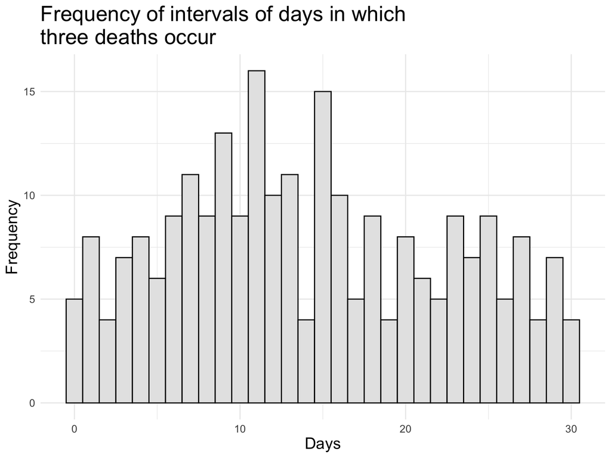

```r
p <- lagged %>%
  ggplot(aes(x = Days_Interval))

p <- p +
  geom_histogram(binwidth = 1, color = "black", fill = "gray90") +
  labs(x = "Days", y = "Frequency") +
  ggtitle("Frequency of intervals of days in which\nthree deaths occur") +
  theme_minimal() +
  theme(axis.text = element_text(size = 10),
        axis.title = element_text(size = 15),
        plot.title = element_text(size = 20))

p
```

This already look interesting!

## Deat distribution by sex

Just to have a deeper look, let’s also divide the count per sex:

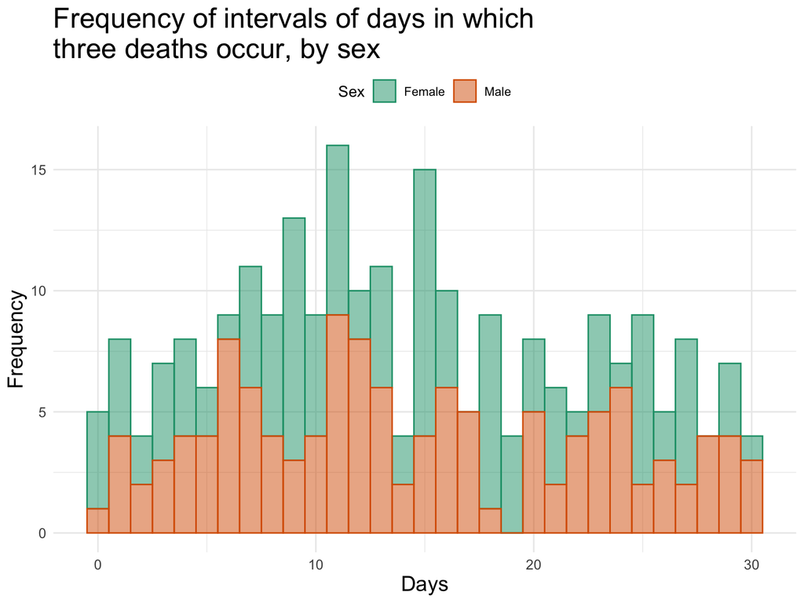

```r
p <- lagged %>%
  ggplot(aes(x = Days_Interval, color = Sex, fill = Sex))

p <- p +
  geom_histogram(binwidth = 1, alpha = 0.5) +
  labs(x = "Days", y = "Frequency") +
  ggtitle("Frequency of intervals of days in which\nthree deaths occur, by sex") +
  scale_fill_brewer(labels = c("Female", "Male"), palette = "Dark2") +
  scale_color_brewer(labels = c("Female", "Male"), palette = "Dark2") +
  theme_minimal() +
  theme(axis.text = element_text(size = 10),
        axis.title = element_text(size = 15),
        legend.position = "top",
        plot.title = element_text(size = 20))

p
```

## Death distribution by year

Finally, it would also be interesting to check whether this distribution changed through the years. Maybe the old saying had once a base of truth?

In order to do so, let’s plot again the same lagged intervals, but this time creating one sub-plot per year:

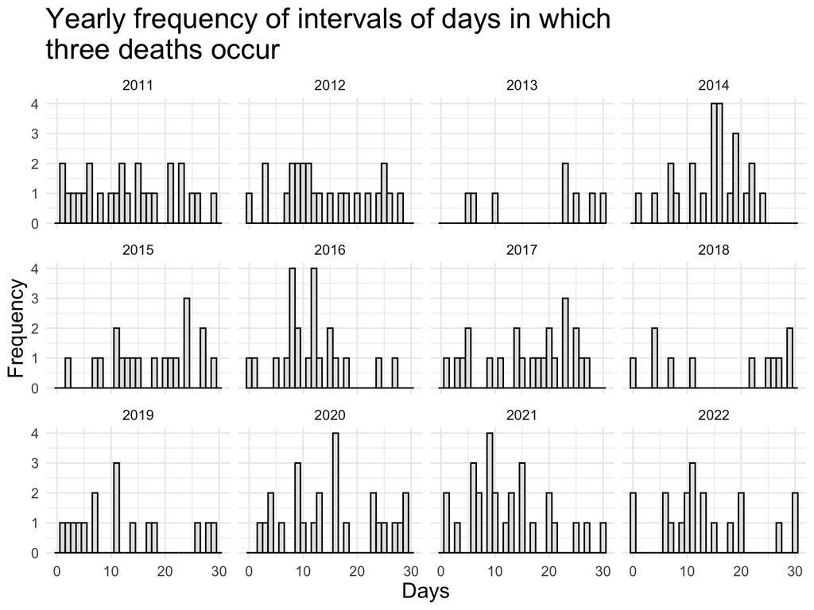

```r
p <- lagged %>%
  group_by(Year) %>%
  ggplot(aes(x = Days_Interval))

p <- p +
  geom_histogram(binwidth = 1, color = "black", fill = "gray90") +
  facet_wrap(~ Year) +
  labs(x = "Days", y = "Frequency") +
  ggtitle("Yearly frequency of intervals of days in which\nthree deaths occur") +
  theme_minimal() +
  theme(axis.text = element_text(size = 10),
        axis.title = element_text(size = 15),
        strip.text = element_text(size = 10),
        plot.title = element_text(size = 20))

p
```

As we can see from the plots, there is some quite variation across the years. However, all plots show either a flat distribution of intervals, or a peak in the center (or sometimes even right!) region.

# Conclusions

This little project tried to investigate whether there was any truth behind the old saying from my hometown in south Italy that “people always die in groups of three”.  
While the spirit of the ‘investigation’ was quite ironical, I took this as a short exercise for me to work with time-series and open-access data.

After playing with the data at hands, I think it is possible to provide an answer to the original question:

> Data do not support the old saying that “people always die in groups of three” in my hometown.  
> Looking at the data in the period 2011-2022, it appears that three successive deaths can happen as easly in a short number of days, as in a longer interval, up to a month!  
> It remains interesting to understand why this saying originated in the first place. Older historical data would maybe help provide a more comprehensive picture. Unfortunately, at the moment it does not seem to be possible to retrieve data at this granular level dating before 2011.